# MINI PROJECT HOTEL BOOKINGS DATA ANALYSIS

Heba

2026-01-01

### Objective:

The objective of this analysis is to understand hotel booking behavior by exploring lead time, market segments, and booking patterns across different hotel types. This report demonstrates data cleaning, transformation, visualization, and reporting using R.

### Load Required Packages in console:

install.packages(c(“tidyverse”, “skimr”, “janitor”, “lubridate”))

### Use them:

```r
library(tidyverse)
library(skimr)
library(janitor)
library(lubridate)
```

### Import the Dataset

```r
hotel_bookings <- read_csv("hotel_bookings.csv")
```

Understand the Data:

```r
head(hotel_bookings)
```

```
## # A tibble: 6 × 32
##   hotel        is_canceled lead_time arrival_date_year arrival_date_month
##   <chr>              <dbl>     <dbl>             <dbl> <chr>
## 1 Resort Hotel           0       342              2015 July
## 2 Resort Hotel           0       737              2015 July
## 3 Resort Hotel           0         7              2015 July
## 4 Resort Hotel           0        13              2015 July
## 5 Resort Hotel           0        14              2015 July
## 6 Resort Hotel           0        14              2015 July
## # ℹ 27 more variables: arrival_date_week_number <dbl>,
## #   arrival_date_day_of_month <dbl>, stays_in_weekend_nights <dbl>,
## #   stays_in_week_nights <dbl>, adults <dbl>, children <dbl>, babies <dbl>,
## #   meal <chr>, country <chr>, market_segment <chr>,
## #   distribution_channel <chr>, is_repeated_guest <dbl>,
## #   previous_cancellations <dbl>, previous_bookings_not_canceled <dbl>,
## #   reserved_room_type <chr>, assigned_room_type <chr>, …
```

```r
glimpse(hotel_bookings)
```

```
## Rows: 119,390
## Columns: 32
## $ hotel                          <chr> "Resort Hotel", "Resort Hotel", "Resort…
## $ is_canceled                    <dbl> 0, 0, 0, 0, 0, 0, 0, 0, 1, 1, 1, 0, 0, …
## $ lead_time                      <dbl> 342, 737, 7, 13, 14, 14, 0, 9, 85, 75, …
## $ arrival_date_year              <dbl> 2015, 2015, 2015, 2015, 2015, 2015, 201…
## $ arrival_date_month             <chr> "July", "July", "July", "July", "July",…
## $ arrival_date_week_number       <dbl> 27, 27, 27, 27, 27, 27, 27, 27, 27, 27,…
## $ arrival_date_day_of_month      <dbl> 1, 1, 1, 1, 1, 1, 1, 1, 1, 1, 1, 1, 1, …
## $ stays_in_weekend_nights        <dbl> 0, 0, 0, 0, 0, 0, 0, 0, 0, 0, 0, 0, 0, …
## $ stays_in_week_nights           <dbl> 0, 0, 1, 1, 2, 2, 2, 2, 3, 3, 4, 4, 4, …
## $ adults                         <dbl> 2, 2, 1, 1, 2, 2, 2, 2, 2, 2, 2, 2, 2, …
## $ children                       <dbl> 0, 0, 0, 0, 0, 0, 0, 0, 0, 0, 0, 0, 0, …
## $ babies                         <dbl> 0, 0, 0, 0, 0, 0, 0, 0, 0, 0, 0, 0, 0, …
## $ meal                           <chr> "BB", "BB", "BB", "BB", "BB", "BB", "BB…
```

[output cut: 19 more lines]

```r
skim_without_charts(hotel_bookings)
```

Data summary

| Name | hotel_bookings |
| --- | --- |
| Number of rows | 119390 |
| Number of columns | 32 |
| _______________________ |  |
| Column type frequency: |  |
| character | 13 |
| Date | 1 |
| numeric | 18 |
| ________________________ |  |
| Group variables | None |

**Variable type: character**

| skim_variable | n_missing | complete_rate | min | max | empty | n_unique | whitespace |
| --- | --- | --- | --- | --- | --- | --- | --- |
| hotel | 0 | 1 | 10 | 12 | 0 | 2 | 0 |
| arrival_date_month | 0 | 1 | 3 | 9 | 0 | 12 | 0 |
| meal | 0 | 1 | 2 | 9 | 0 | 5 | 0 |
| country | 0 | 1 | 2 | 4 | 0 | 178 | 0 |
| market_segment | 0 | 1 | 6 | 13 | 0 | 8 | 0 |
| distribution_channel | 0 | 1 | 3 | 9 | 0 | 5 | 0 |
| reserved_room_type | 0 | 1 | 1 | 1 | 0 | 10 | 0 |
| assigned_room_type | 0 | 1 | 1 | 1 | 0 | 12 | 0 |
| deposit_type | 0 | 1 | 10 | 10 | 0 | 3 | 0 |
| agent | 0 | 1 | 1 | 4 | 0 | 334 | 0 |
| company | 0 | 1 | 1 | 4 | 0 | 353 | 0 |
| customer_type | 0 | 1 | 5 | 15 | 0 | 4 | 0 |
| reservation_status | 0 | 1 | 7 | 9 | 0 | 3 | 0 |

**Variable type: Date**

| skim_variable | n_missing | complete_rate | min | max | median | n_unique |
| --- | --- | --- | --- | --- | --- | --- |
| reservation_status_date | 0 | 1 | 2014-10-17 | 2017-09-14 | 2016-08-07 | 926 |

**Variable type: numeric**

| skim_variable | n_missing | complete_rate | mean | sd | p0 | p25 | p50 | p75 | p100 |
| --- | --- | --- | --- | --- | --- | --- | --- | --- | --- |
| is_canceled | 0 | 1 | 0.37 | 0.48 | 0.00 | 0.00 | 0.00 | 1 | 1 |
| lead_time | 0 | 1 | 104.01 | 106.86 | 0.00 | 18.00 | 69.00 | 160 | 737 |
| arrival_date_year | 0 | 1 | 2016.16 | 0.71 | 2015.00 | 2016.00 | 2016.00 | 2017 | 2017 |
| arrival_date_week_number | 0 | 1 | 27.17 | 13.61 | 1.00 | 16.00 | 28.00 | 38 | 53 |
| arrival_date_day_of_month | 0 | 1 | 15.80 | 8.78 | 1.00 | 8.00 | 16.00 | 23 | 31 |
| stays_in_weekend_nights | 0 | 1 | 0.93 | 1.00 | 0.00 | 0.00 | 1.00 | 2 | 19 |
| stays_in_week_nights | 0 | 1 | 2.50 | 1.91 | 0.00 | 1.00 | 2.00 | 3 | 50 |
| adults | 0 | 1 | 1.86 | 0.58 | 0.00 | 2.00 | 2.00 | 2 | 55 |
| children | 4 | 1 | 0.10 | 0.40 | 0.00 | 0.00 | 0.00 | 0 | 10 |
| babies | 0 | 1 | 0.01 | 0.10 | 0.00 | 0.00 | 0.00 | 0 | 10 |
| is_repeated_guest | 0 | 1 | 0.03 | 0.18 | 0.00 | 0.00 | 0.00 | 0 | 1 |
| previous_cancellations | 0 | 1 | 0.09 | 0.84 | 0.00 | 0.00 | 0.00 | 0 | 26 |
| previous_bookings_not_canceled | 0 | 1 | 0.14 | 1.50 | 0.00 | 0.00 | 0.00 | 0 | 72 |
| booking_changes | 0 | 1 | 0.22 | 0.65 | 0.00 | 0.00 | 0.00 | 0 | 21 |
| days_in_waiting_list | 0 | 1 | 2.32 | 17.59 | 0.00 | 0.00 | 0.00 | 0 | 391 |
| adr | 0 | 1 | 101.83 | 50.54 | -6.38 | 69.29 | 94.58 | 126 | 5400 |
| required_car_parking_spaces | 0 | 1 | 0.06 | 0.25 | 0.00 | 0.00 | 0.00 | 0 | 8 |
| total_of_special_requests | 0 | 1 | 0.57 | 0.79 | 0.00 | 0.00 | 0.00 | 1 | 5 |

This step helps identify data types, missing values, and overall structure before cleaning.

### Data Cleaning

```r
hotel_bookings_clean <- hotel_bookings %>%
  clean_names() %>%
  select(
    hotel,
    is_canceled,
    lead_time,
    children,
    market_segment,
    arrival_date_year
  )
```

Explanation:

clean_names() standardizes column names

select() keeps only relevant variables

### Data Transformation:

```r
hotel_bookings_clean <- hotel_bookings_clean %>%
  mutate(
    has_children = children > 0
  )
```

Explanation: A new logical variable has_children was created to identify bookings with children.

### Summary Analysis -

```r
lead_time_summary <- hotel_bookings_clean %>%
  group_by(hotel) %>%
  summarize(
    avg_lead_time = mean(lead_time, na.rm = TRUE),
    max_lead_time = max(lead_time, na.rm = TRUE)
  )
```

## Visualization 1: Lead Time vs Number of Children

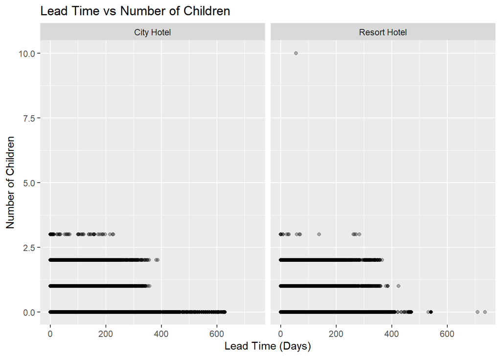

```r
ggplot(hotel_bookings_clean) +
  geom_point(
    aes(x = lead_time, y = children),
    alpha = 0.3
  ) +
  facet_wrap(~hotel) +
  labs(
    title = "Lead Time vs Number of Children",
    x = "Lead Time (Days)",
    y = "Number of Children"
  )
```

### Data Time Range:

```r
min_year <- min(hotel_bookings_clean$arrival_date_year)
max_year <- max(hotel_bookings_clean$arrival_date_year)
```

## Visualization 2: Market Segment Distribution

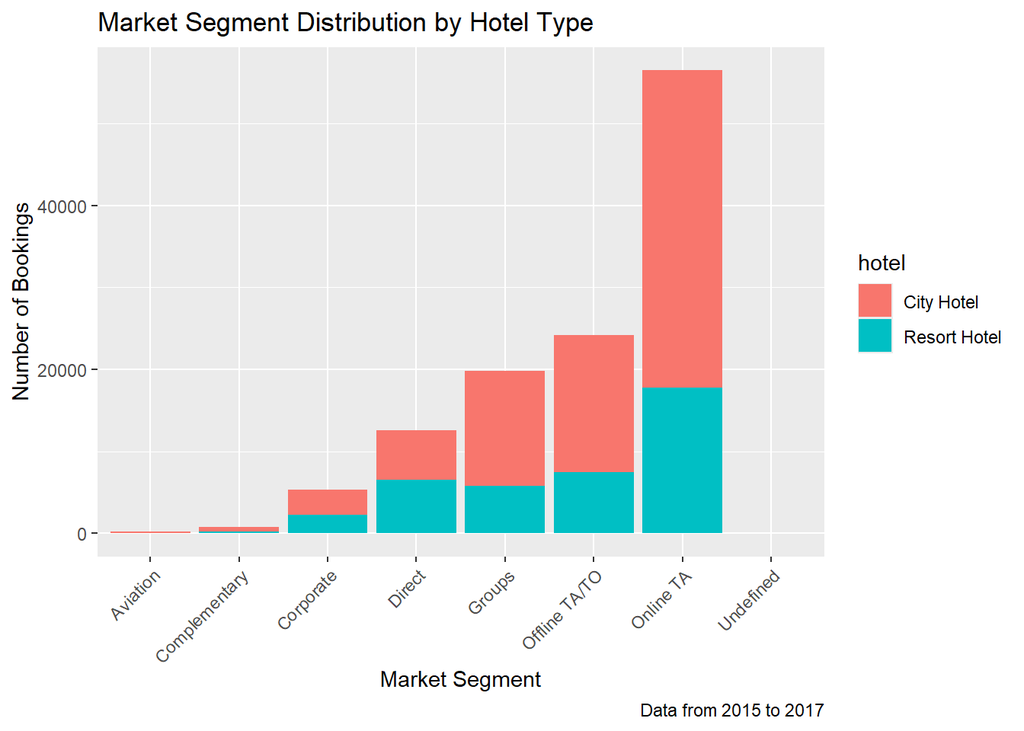

```r
ggplot(hotel_bookings_clean) +
  geom_bar(
    aes(x = market_segment, fill = hotel)
  ) +
  labs(
    title = "Market Segment Distribution by Hotel Type",
    x = "Market Segment",
    y = "Number of Bookings",
    caption = paste0("Data from ", min_year, " to ", max_year)
  ) +
  theme(axis.text.x = element_text(angle = 45, hjust = 1))
```

### Saving a Plot:

```r
ggsave("hotel_booking_analysis.png", width = 16, height = 8)
```

### Conclusion:

This analysis demonstrates how R can be used to clean, transform, analyze, and visualize real-world data. Using tidyverse tools and ggplot2, meaningful insights were derived from hotel booking data. The use of R Markdown ensures that the analysis is transparent, reproducible, and easy to share.